# Biostat 212a Homework 1

Due Jan 23, 2024 @ 11:59PM

Author

Published

February 11, 2025

```r
library(ISLR2)
library(GGally) # ggpairs function
library(tidyverse)
library(pROC)
```

## 1 Filling gaps in lecture notes (10pts)

Consider the regression model
$$Y = f(X) + \epsilon,$$
where $\operatorname{E}(\epsilon) = 0$.

### 1.1 Optimal regression function

Show that the choice
$$f_{\text{opt}}(X) = \operatorname{E}(Y | X)$$
minimizes the mean squared prediction error
$$\operatorname{E}[Y - f(X)]^2,$$
where the expectations averages over variations in both $X$ and $Y$. (Hint: condition on $X$.)

**Solution**

Conditioning on $X$
$$\begin{eqnarray*}
\operatorname{E}[Y - f(X)]^2 &=& \operatorname{E}_X \operatorname{E}_{Y \mid X} \{ [Y - f(X)]^2 \mid X \}.
\end{eqnarray*}$$
Now at $X=x$,
$$\begin{eqnarray*}
\operatorname{E}_{Y \mid X} [ (Y - c)^2 \mid X = x ] &=& \int (y - c)^2 \, dF_{Y\mid X=x}(y)
\end{eqnarray*}$$
is minimized by $c(x) = \operatorname{E}_{Y \mid X = x}(Y \mid X = x)$. Therefore $f_{\text{opt}}$ minimizes the mean squared prediction error.

### 1.2 Bias-variance trade-off

Given an estimate $\hat f$ of $f$, show that the test error at a $x_0$ can be decomposed as
$$\operatorname{E}[y_0 - \hat f(x_0)]^2 = \underbrace{\operatorname{Var}(\hat f(x_0)) + [\operatorname{Bias}(\hat f(x_0))]^2}_{\text{MSE of } \hat f(x_0) \text{ for estimating } f(x_0)} + \underbrace{\operatorname{Var}(\epsilon)}_{\text{irreducible}},$$
where the expectation averages over the variability in $y_0$ and $\hat f$.

**Solution**

$$\begin{eqnarray*}
& & \operatorname{E}_{y_0,\hat f}(y_0 - \hat f(x_0))^2 \\
&=& \operatorname{E}_{y_0,\hat f} (y_0 - f(x_0) + f(x_0) - \hat f(x_0))^2 \\
&=& \operatorname{E}_{y_0,\hat f} (y_0 - f(x_0))^2 + 2 \operatorname{E}_{y_0,\hat f} (y_0 - f(x_0))(f(x_0) - \hat f(x_0)) + \operatorname{E}_{y_0,\hat f} (f(x_0) - \hat f(x_0))^2 \\
&=& \operatorname{Var}(\epsilon) + 0 + \operatorname{E}_{\hat f} (f(x_0) - \hat f(x_0))^2 \\
&=& \operatorname{Var}(\epsilon) + \operatorname{E}_{\hat f} (f(x_0) - \operatorname{E}_{\hat f} \hat f(x_0) + \operatorname{E}_{\hat f} \hat f(x_0) - \hat f(x_0))^2 \\
&=& \operatorname{Var}(\epsilon) + \operatorname{E}_{\hat f} (f(x_0) - \operatorname{E}_{\hat f} \hat f(x_0))^2 + 2 \operatorname{E}_{\hat f} [(f(x_0) - \operatorname{E}_{\hat f} \hat f(x_0))(\operatorname{E}_{\hat f} \hat f(x_0) - \hat f(x_0))] + \operatorname{E}_{\hat f} (\operatorname{E}_{\hat f} \hat f(x_0) - \hat f(x_0))^2 \\
&=& \operatorname{Var}(\epsilon) + (f(x_0) - \operatorname{E}_{\hat f} \hat f(x_0))^2 + 0 + \operatorname{Var}(\hat f(x_0)) \\
&=& \operatorname{Var}(\epsilon) + [\operatorname{Bias}(\hat f(x_0))]^2 + \operatorname{Var}(\hat f(x_0)).
\end{eqnarray*}$$

## 2 ISL Exercise 2.4.3 (10pts)

We now revisit the bias-variance decomposition.

1. Provide a sketch of typical (squared) bias, variance, training error, test error, and Bayes (or irreducible) error curves, on a single plot, as we go from less flexible statistical learning methods towards more flexible approaches. The x-axis should represent the amount of flexibility in the method, and the y-axis should represent the values for each curve. There should be five curves. Make sure to label each one.

2. Explain why each of the five curves has the shape displayed in part (a).

## 3 ISL Exercise 2.4.4 (10pts)

You will now think of some real-life applications for statistical learning.

1. Describe three real-life applications in which classification might be useful. Describe the response, as well as the predictors. Is the goal of each application inference or prediction? Explain your answer.

**Solution**

1. Among lung transplant patients, acute rejection is deadly. The goal of the study is to use each patients gene expression data from blood to classify who will develop acute rejection who will not. The predictors are gene expression, the outcome is the acute rejection. The primary goal is prediction.
2. Same problem as above, the goal is to identify genes that are differential expressed between reject and not reject. The primay goal is inference.
2. Describe three real-life applications in which regression might be useful. Describe the response, as well as the predictors. Is the goal of each application inference or prediction? Explain your answer.

**Solution**

1. Identify the factors that are associated with kids’ exam scores. These factors include, class size, number of TAs, experiences of the teachers (years), kids’ entrance exam score. Inference.
2. Patient Length of Stay (LOS) in hospital or ER.Prediction
3. Describe three real-life applications in which cluster analysis might be useful.

**Solution**

1. Identify subtypes of a complex diseases, e.g., diabetes. Features include biomarkers, vital signs, medical history, etc.
2. Identify ethnicity groups based on genetic data.
3. Identify diseased areas in diagnostic images like X-rays that are abnormal.

## 4 ISL Exercise 2.4.10 (30pts)

Your can read in the `boston` data set directly from url https://raw.githubusercontent.com/ucla-econ-425t/2023winter/master/slides/data/Boston.csv. A documentation of the `boston` data set is [here](https://www.rdocumentation.org/packages/ISLR2/versions/1.3-2/topics/Boston).

**Python**

```python
import pandas as pd
import io
import requests

# Display all columns
pd.set_option('display.max_columns', None)

url = "https://raw.githubusercontent.com/ucla-econ-425t/2023winter/master/slides/data/Boston.csv"
s = requests.get(url).content
Boston = pd.read_csv(
  io.StringIO(s.decode('utf-8')),
  index_col = 0,
  # dtype = {'chas': 'category'}
  )
Boston
```

```
        crim    zn  indus  chas    nox     rm   age     dis  rad  tax  \
1    0.00632  18.0   2.31     0  0.538  6.575  65.2  4.0900    1  296
2    0.02731   0.0   7.07     0  0.469  6.421  78.9  4.9671    2  242
3    0.02729   0.0   7.07     0  0.469  7.185  61.1  4.9671    2  242
4    0.03237   0.0   2.18     0  0.458  6.998  45.8  6.0622    3  222
5    0.06905   0.0   2.18     0  0.458  7.147  54.2  6.0622    3  222
..       ...   ...    ...   ...    ...    ...   ...     ...  ...  ...
502  0.06263   0.0  11.93     0  0.573  6.593  69.1  2.4786    1  273
503  0.04527   0.0  11.93     0  0.573  6.120  76.7  2.2875    1  273
504  0.06076   0.0  11.93     0  0.573  6.976  91.0  2.1675    1  273
505  0.10959   0.0  11.93     0  0.573  6.794  89.3  2.3889    1  273
506  0.04741   0.0  11.93     0  0.573  6.030  80.8  2.5050    1  273

     ptratio  lstat  medv
1       15.3   4.98  24.0
2       17.8   9.14  21.6
3       17.8   4.03  34.7
4       18.7   2.94  33.4
5       18.7   5.33  36.2
..       ...    ...   ...
502     21.0   9.67  22.4
503     21.0   9.08  20.6
504     21.0   5.64  23.9
505     21.0   6.48  22.0
506     21.0   7.88  11.9

[506 rows x 13 columns]
```

**R**

```r
library(tidyverse)

Boston <- read_csv("https://raw.githubusercontent.com/ucla-econ-425t/2023winter/master/slides/data/Boston.csv", col_select = -1) %>%
  print(width = Inf)
```

```
# A tibble: 506 × 13
      crim    zn indus  chas   nox    rm   age   dis   rad   tax ptratio lstat
     <dbl> <dbl> <dbl> <dbl> <dbl> <dbl> <dbl> <dbl> <dbl> <dbl>   <dbl> <dbl>
 1 0.00632  18    2.31     0 0.538  6.58  65.2  4.09     1   296    15.3  4.98
 2 0.0273    0    7.07     0 0.469  6.42  78.9  4.97     2   242    17.8  9.14
 3 0.0273    0    7.07     0 0.469  7.18  61.1  4.97     2   242    17.8  4.03
 4 0.0324    0    2.18     0 0.458  7.00  45.8  6.06     3   222    18.7  2.94
 5 0.0690    0    2.18     0 0.458  7.15  54.2  6.06     3   222    18.7  5.33
 6 0.0298    0    2.18     0 0.458  6.43  58.7  6.06     3   222    18.7  5.21
 7 0.0883   12.5  7.87     0 0.524  6.01  66.6  5.56     5   311    15.2 12.4
 8 0.145    12.5  7.87     0 0.524  6.17  96.1  5.95     5   311    15.2 19.2
 9 0.211    12.5  7.87     0 0.524  5.63 100    6.08     5   311    15.2 29.9
10 0.170    12.5  7.87     0 0.524  6.00  85.9  6.59     5   311    15.2 17.1
    medv
   <dbl>
 1  24
 2  21.6
 3  34.7
 4  33.4
 5  36.2
 6  28.7
 7  22.9
 8  27.1
 9  16.5
10  18.9
# ℹ 496 more rows
```

This exercise involves the Boston housing data set.

### 4.1 (a)

How many rows are in this data set? How many columns? What do the rows and columns represent?

**Solution**

There are 506 rows and 13 columns in the `boston` data set. Each row is a suburb of Boston. Each column is a variable being measured on suburbs.

**R**

```r
library(gtsummary)

dim(Boston)
```

```
[1] 506  13
```

```r
Boston %>% tbl_summary()
```

| **Characteristic** | **N = 506** <sup>1</sup> |
| --- | --- |
| crim | 0.3 (0.1, 3.7) |
| zn | 0 (0, 13) |
| indus | 9.7 (5.2, 18.1) |
| chas | 35 (6.9%) |
| nox | 0.54 (0.45, 0.62) |
| rm | 6.21 (5.89, 6.63) |
| age | 78 (45, 94) |
| dis | 3.21 (2.10, 5.21) |
| rad |  |
| 1 | 20 (4.0%) |
| 2 | 24 (4.7%) |
| 3 | 38 (7.5%) |
| 4 | 110 (22%) |
| 5 | 115 (23%) |
| 6 | 26 (5.1%) |
| 7 | 17 (3.4%) |
| 8 | 24 (4.7%) |
| 24 | 132 (26%) |
| tax | 330 (279, 666) |
| ptratio | 19.05 (17.40, 20.20) |
| lstat | 11 (7, 17) |
| medv | 21 (17, 25) |

<sup>1</sup> Median (Q1, Q3); n (%)

**Python**

```python
Boston.shape
```

```
(506, 13)
```

### 4.2 (b)

Make some pairwise scatterplots of the predictors (columns) in this data set. Describe your findings.

**Solution**

We can use `pairplot` in Seaborn package for the pairwise scatter plots. It seems that `zn` is correlated with `rm` and `dis`. `indus` is correlated with `nox`.

**R**

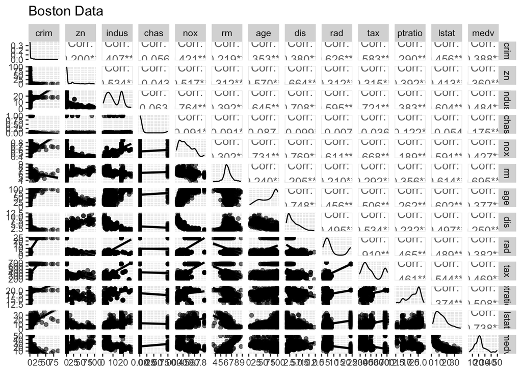

```r
library(GGally)

# Graphical summary
ggpairs(
  data = Boston,
  mapping = aes(alpha = 0.25),
  lower = list(continuous = "smooth")
  ) +
  labs(title = "Boston Data")
```

```r
# Numerical summary
summary(Boston)
```

```
      crim                zn             indus            chas
 Min.   : 0.00632   Min.   :  0.00   Min.   : 0.46   Min.   :0.00000
 1st Qu.: 0.08205   1st Qu.:  0.00   1st Qu.: 5.19   1st Qu.:0.00000
 Median : 0.25651   Median :  0.00   Median : 9.69   Median :0.00000
 Mean   : 3.61352   Mean   : 11.36   Mean   :11.14   Mean   :0.06917
 3rd Qu.: 3.67708   3rd Qu.: 12.50   3rd Qu.:18.10   3rd Qu.:0.00000
 Max.   :88.97620   Max.   :100.00   Max.   :27.74   Max.   :1.00000
      nox               rm             age              dis
 Min.   :0.3850   Min.   :3.561   Min.   :  2.90   Min.   : 1.130
 1st Qu.:0.4490   1st Qu.:5.886   1st Qu.: 45.02   1st Qu.: 2.100
 Median :0.5380   Median :6.208   Median : 77.50   Median : 3.207
 Mean   :0.5547   Mean   :6.285   Mean   : 68.57   Mean   : 3.795
 3rd Qu.:0.6240   3rd Qu.:6.623   3rd Qu.: 94.08   3rd Qu.: 5.188
 Max.   :0.8710   Max.   :8.780   Max.   :100.00   Max.   :12.127
      rad              tax           ptratio          lstat
 Min.   : 1.000   Min.   :187.0   Min.   :12.60   Min.   : 1.73
 1st Qu.: 4.000   1st Qu.:279.0   1st Qu.:17.40   1st Qu.: 6.95
 Median : 5.000   Median :330.0   Median :19.05   Median :11.36
 Mean   : 9.549   Mean   :408.2   Mean   :18.46   Mean   :12.65
 3rd Qu.:24.000   3rd Qu.:666.0   3rd Qu.:20.20   3rd Qu.:16.95
 Max.   :24.000   Max.   :711.0   Max.   :22.00   Max.   :37.97
      medv
 Min.   : 5.00
 1st Qu.:17.02
 Median :21.20
 Mean   :22.53
 3rd Qu.:25.00
 Max.   :50.00
```

**Python**

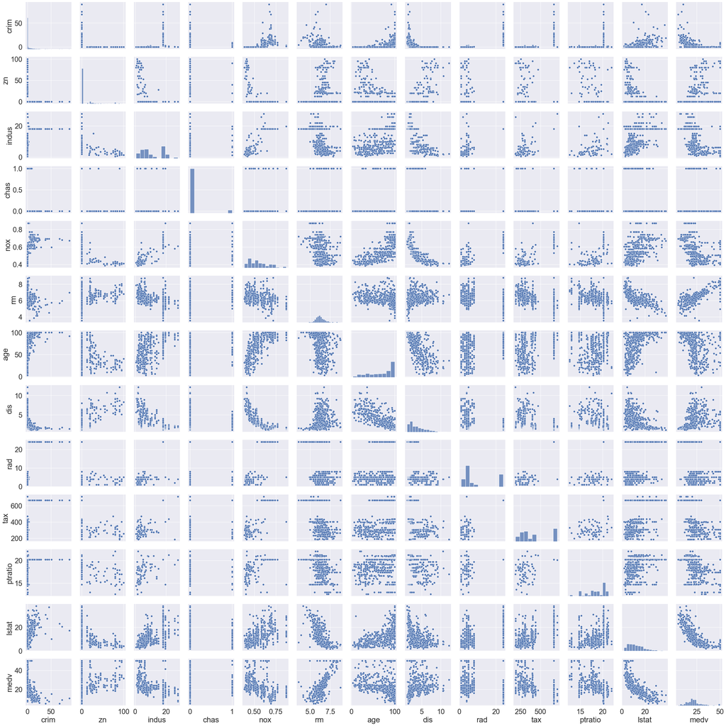

[figure not shown]

```python
import seaborn as sns
import matplotlib.pyplot as plt
# Set font sizes in plots
sns.set(font_scale = 2)

# Graphical summary
sns.pairplot(data = Boston)
```

```python
# Numerical summary
Boston.describe()
```

```
             crim          zn       indus        chas         nox          rm  \
count  506.000000  506.000000  506.000000  506.000000  506.000000  506.000000
mean     3.613524   11.363636   11.136779    0.069170    0.554695    6.284634
std      8.601545   23.322453    6.860353    0.253994    0.115878    0.702617
min      0.006320    0.000000    0.460000    0.000000    0.385000    3.561000
25%      0.082045    0.000000    5.190000    0.000000    0.449000    5.885500
50%      0.256510    0.000000    9.690000    0.000000    0.538000    6.208500
75%      3.677083   12.500000   18.100000    0.000000    0.624000    6.623500
max     88.976200  100.000000   27.740000    1.000000    0.871000    8.780000

              age         dis         rad         tax     ptratio       lstat  \
count  506.000000  506.000000  506.000000  506.000000  506.000000  506.000000
mean    68.574901    3.795043    9.549407  408.237154   18.455534   12.653063
std     28.148861    2.105710    8.707259  168.537116    2.164946    7.141062
min      2.900000    1.129600    1.000000  187.000000   12.600000    1.730000
25%     45.025000    2.100175    4.000000  279.000000   17.400000    6.950000
50%     77.500000    3.207450    5.000000  330.000000   19.050000   11.360000
75%     94.075000    5.188425   24.000000  666.000000   20.200000   16.955000
max    100.000000   12.126500   24.000000  711.000000   22.000000   37.970000

             medv
count  506.000000
mean    22.532806
std      9.197104
min      5.000000
25%     17.025000
50%     21.200000
75%     25.000000
max     50.000000
```

### 4.3 (c)

Are any of the predictors associated with per capita crime rate? If so, explain the relationship.

**Solution**

- `crim` seems to be highly correlated with `indus`, `nox`, `rad`, `tax`, and `lstat`, all with Pearson correlation larger than 0.4.

**R**

```r
cor(Boston, method = "pearson") %>% round(digits = 2)
```

```
         crim    zn indus  chas   nox    rm   age   dis   rad   tax ptratio
crim     1.00 -0.20  0.41 -0.06  0.42 -0.22  0.35 -0.38  0.63  0.58    0.29
zn      -0.20  1.00 -0.53 -0.04 -0.52  0.31 -0.57  0.66 -0.31 -0.31   -0.39
indus    0.41 -0.53  1.00  0.06  0.76 -0.39  0.64 -0.71  0.60  0.72    0.38
chas    -0.06 -0.04  0.06  1.00  0.09  0.09  0.09 -0.10 -0.01 -0.04   -0.12
nox      0.42 -0.52  0.76  0.09  1.00 -0.30  0.73 -0.77  0.61  0.67    0.19
rm      -0.22  0.31 -0.39  0.09 -0.30  1.00 -0.24  0.21 -0.21 -0.29   -0.36
age      0.35 -0.57  0.64  0.09  0.73 -0.24  1.00 -0.75  0.46  0.51    0.26
dis     -0.38  0.66 -0.71 -0.10 -0.77  0.21 -0.75  1.00 -0.49 -0.53   -0.23
rad      0.63 -0.31  0.60 -0.01  0.61 -0.21  0.46 -0.49  1.00  0.91    0.46
tax      0.58 -0.31  0.72 -0.04  0.67 -0.29  0.51 -0.53  0.91  1.00    0.46
ptratio  0.29 -0.39  0.38 -0.12  0.19 -0.36  0.26 -0.23  0.46  0.46    1.00
lstat    0.46 -0.41  0.60 -0.05  0.59 -0.61  0.60 -0.50  0.49  0.54    0.37
medv    -0.39  0.36 -0.48  0.18 -0.43  0.70 -0.38  0.25 -0.38 -0.47   -0.51
        lstat  medv
crim     0.46 -0.39
zn      -0.41  0.36
indus    0.60 -0.48
chas    -0.05  0.18
nox      0.59 -0.43
rm      -0.61  0.70
age      0.60 -0.38
dis     -0.50  0.25
rad      0.49 -0.38
tax      0.54 -0.47
ptratio  0.37 -0.51
lstat    1.00 -0.74
medv    -0.74  1.00
```

**Python**

```python
round(Boston.corr(), 2)
```

```
         crim    zn  indus  chas   nox    rm   age   dis   rad   tax  ptratio  \
crim     1.00 -0.20   0.41 -0.06  0.42 -0.22  0.35 -0.38  0.63  0.58     0.29
zn      -0.20  1.00  -0.53 -0.04 -0.52  0.31 -0.57  0.66 -0.31 -0.31    -0.39
indus    0.41 -0.53   1.00  0.06  0.76 -0.39  0.64 -0.71  0.60  0.72     0.38
chas    -0.06 -0.04   0.06  1.00  0.09  0.09  0.09 -0.10 -0.01 -0.04    -0.12
nox      0.42 -0.52   0.76  0.09  1.00 -0.30  0.73 -0.77  0.61  0.67     0.19
rm      -0.22  0.31  -0.39  0.09 -0.30  1.00 -0.24  0.21 -0.21 -0.29    -0.36
age      0.35 -0.57   0.64  0.09  0.73 -0.24  1.00 -0.75  0.46  0.51     0.26
dis     -0.38  0.66  -0.71 -0.10 -0.77  0.21 -0.75  1.00 -0.49 -0.53    -0.23
rad      0.63 -0.31   0.60 -0.01  0.61 -0.21  0.46 -0.49  1.00  0.91     0.46
tax      0.58 -0.31   0.72 -0.04  0.67 -0.29  0.51 -0.53  0.91  1.00     0.46
ptratio  0.29 -0.39   0.38 -0.12  0.19 -0.36  0.26 -0.23  0.46  0.46     1.00
lstat    0.46 -0.41   0.60 -0.05  0.59 -0.61  0.60 -0.50  0.49  0.54     0.37
medv    -0.39  0.36  -0.48  0.18 -0.43  0.70 -0.38  0.25 -0.38 -0.47    -0.51

         lstat  medv
crim      0.46 -0.39
zn       -0.41  0.36
indus     0.60 -0.48
chas     -0.05  0.18
nox       0.59 -0.43
rm       -0.61  0.70
age       0.60 -0.38
dis      -0.50  0.25
rad       0.49 -0.38
tax       0.54 -0.47
ptratio   0.37 -0.51
lstat     1.00 -0.74
medv     -0.74  1.00
```

### 4.4 (d)

Do any of the census tracts of Boston appear to have particularly high crime rates? Tax rates? Pupil-teacher ratios? Comment on the range of each predictor.

**Solution**

- There seem to be some outliers in `crim` (>20).

**R**

```r
# Numerical summary
Boston %>%
  select(crim, tax, ptratio) %>%
  summary()
```

```
      crim               tax           ptratio
 Min.   : 0.00632   Min.   :187.0   Min.   :12.60
 1st Qu.: 0.08205   1st Qu.:279.0   1st Qu.:17.40
 Median : 0.25651   Median :330.0   Median :19.05
 Mean   : 3.61352   Mean   :408.2   Mean   :18.46
 3rd Qu.: 3.67708   3rd Qu.:666.0   3rd Qu.:20.20
 Max.   :88.97620   Max.   :711.0   Max.   :22.00
```

**Python**

```python
cols = ['crim', 'tax', 'ptratio']
# Numerical summaries
Boston[cols].describe()
```

```
             crim         tax     ptratio
count  506.000000  506.000000  506.000000
mean     3.613524  408.237154   18.455534
std      8.601545  168.537116    2.164946
min      0.006320  187.000000   12.600000
25%      0.082045  279.000000   17.400000
50%      0.256510  330.000000   19.050000
75%      3.677083  666.000000   20.200000
max     88.976200  711.000000   22.000000
```

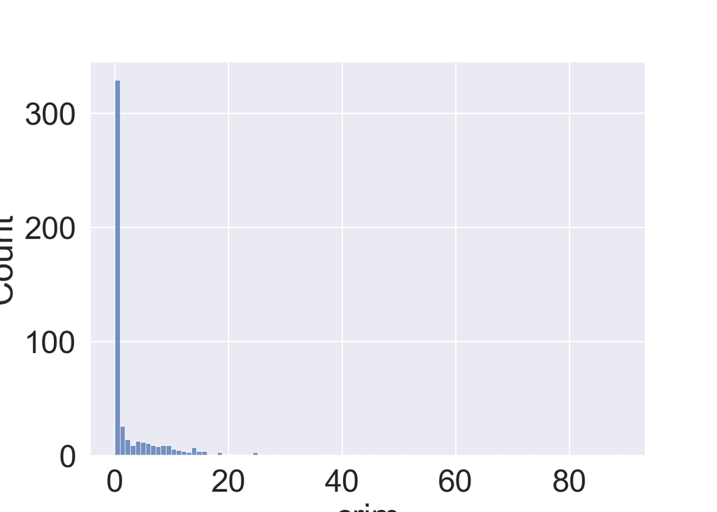

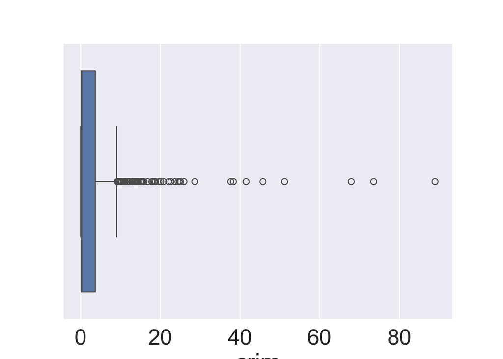

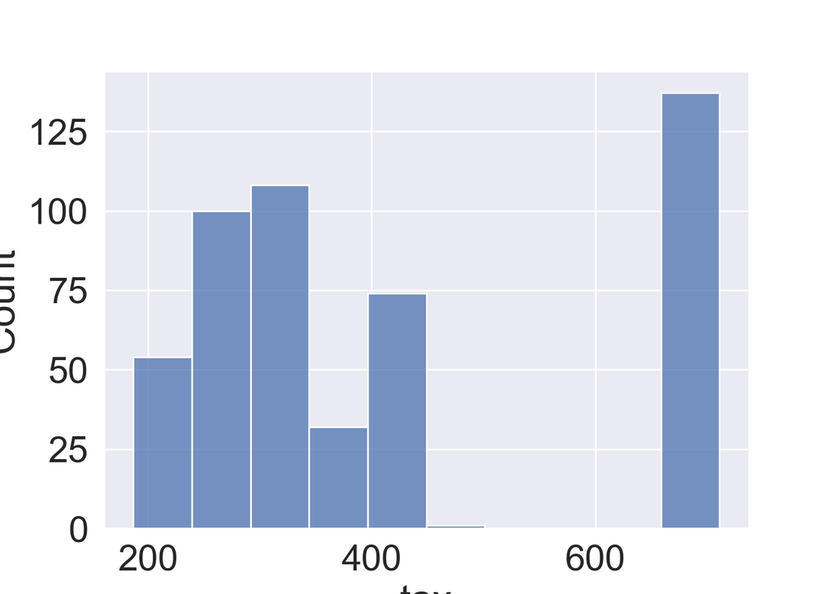

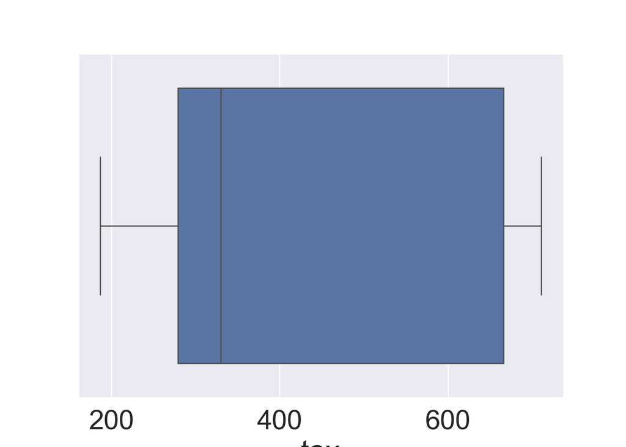

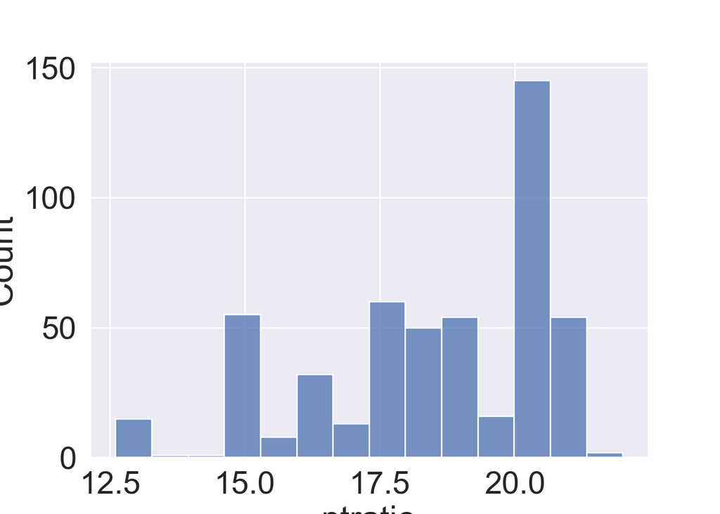

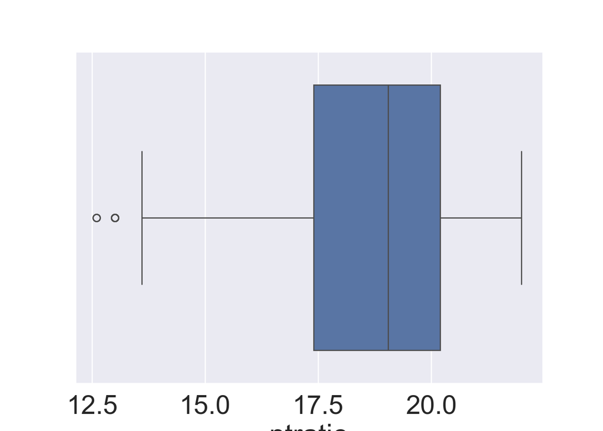

```python
plt.clf()
# Graphical summaries
for i, col in enumerate(cols):
    sns.histplot(data = Boston, x = col)
    plt.show()
    sns.boxplot(data = Boston, x = col)
    plt.show()
```

### 4.5 (e)

How many of the census tracts in this data set bound the Charles river?

**Solution**

35 census tracts bound the Charles river.

**R**

```r
# Frequency table
table(Boston["chas"])
```

```
chas
  0   1
471  35
```

**Python**

```python
# Count the value 1
Boston['chas'].sum()
```

```
np.int64(35)
```

### 4.6 (f)

What is the median pupil-teacher ratio among the towns in this data set?

**Solution**

The median pupil-teacher ratio is 19.05.

**R**

```r
median(Boston$ptratio)
```

```
[1] 19.05
```

**Python**

```python
Boston['ptratio'].describe()
```

```
count    506.000000
mean      18.455534
std        2.164946
min       12.600000
25%       17.400000
50%       19.050000
75%       20.200000
max       22.000000
Name: ptratio, dtype: float64
```

```python
Boston['ptratio'].median()
```

```
np.float64(19.05)
```

### 4.7 (g)

Which census tract of Boston has lowest median value of owner-occupied homes? What are the values of the other predictors for that census tract, and how do those values compare to the overall ranges for those predictors? Comment on your findings.

**Solution**

There are two census tracts with the minimum `medv` 5. They both have relative high `ptratio`

**R**

```r
Boston %>%
  slice_min(medv) %>%
  print(width = Inf)
```

```
# A tibble: 2 × 13
   crim    zn indus  chas   nox    rm   age   dis   rad   tax ptratio lstat
  <dbl> <dbl> <dbl> <dbl> <dbl> <dbl> <dbl> <dbl> <dbl> <dbl>   <dbl> <dbl>
1  38.4     0  18.1     0 0.693  5.45   100  1.49    24   666    20.2  30.6
2  67.9     0  18.1     0 0.693  5.68   100  1.43    24   666    20.2  23.0
   medv
  <dbl>
1     5
2     5
```

**Python**

```python
Boston[Boston['medv'] == Boston['medv'].min()]
```

```
        crim   zn  indus  chas    nox     rm    age     dis  rad  tax  \
399  38.3518  0.0   18.1     0  0.693  5.453  100.0  1.4896   24  666
406  67.9208  0.0   18.1     0  0.693  5.683  100.0  1.4254   24  666

     ptratio  lstat  medv
399     20.2  30.59   5.0
406     20.2  22.98   5.0
```

### 4.8 (h)

In this data set, how many of the census tracts average more than seven rooms per dwelling? More than eight rooms per dwelling? Comment on the census tracts that average more than eight rooms per dwelling.

**Solution**

There are 13 census tracts with more than 8 rooms per dwelling.

**R**

```r
Boston %>%
  filter(rm > 8) %>%
  print(width = Inf)
```

```
# A tibble: 13 × 13
     crim    zn indus  chas   nox    rm   age   dis   rad   tax ptratio lstat
    <dbl> <dbl> <dbl> <dbl> <dbl> <dbl> <dbl> <dbl> <dbl> <dbl>   <dbl> <dbl>
 1 0.121      0  2.89     0 0.445  8.07  76    3.50     2   276    18    4.21
 2 1.52       0 19.6      1 0.605  8.38  93.9  2.16     5   403    14.7  3.32
 3 0.0201    95  2.68     0 0.416  8.03  31.9  5.12     4   224    14.7  2.88
 4 0.315      0  6.2      0 0.504  8.27  78.3  2.89     8   307    17.4  4.14
 5 0.527      0  6.2      0 0.504  8.72  83    2.89     8   307    17.4  4.63
 6 0.382      0  6.2      0 0.504  8.04  86.5  3.22     8   307    17.4  3.13
 7 0.575      0  6.2      0 0.507  8.34  73.3  3.84     8   307    17.4  2.47
 8 0.331      0  6.2      0 0.507  8.25  70.4  3.65     8   307    17.4  3.95
 9 0.369     22  5.86     0 0.431  8.26   8.4  8.91     7   330    19.1  3.54
10 0.612     20  3.97     0 0.647  8.70  86.9  1.80     5   264    13    5.12
11 0.520     20  3.97     0 0.647  8.40  91.5  2.29     5   264    13    5.91
12 0.578     20  3.97     0 0.575  8.30  67    2.42     5   264    13    7.44
```

[output cut: 16 more lines]

**Python**

```python
Boston[Boston['rm'] > 7].shape[0]
```

```
64
```

```python
Boston[Boston['rm'] > 8].shape[0]
```

```
13
```

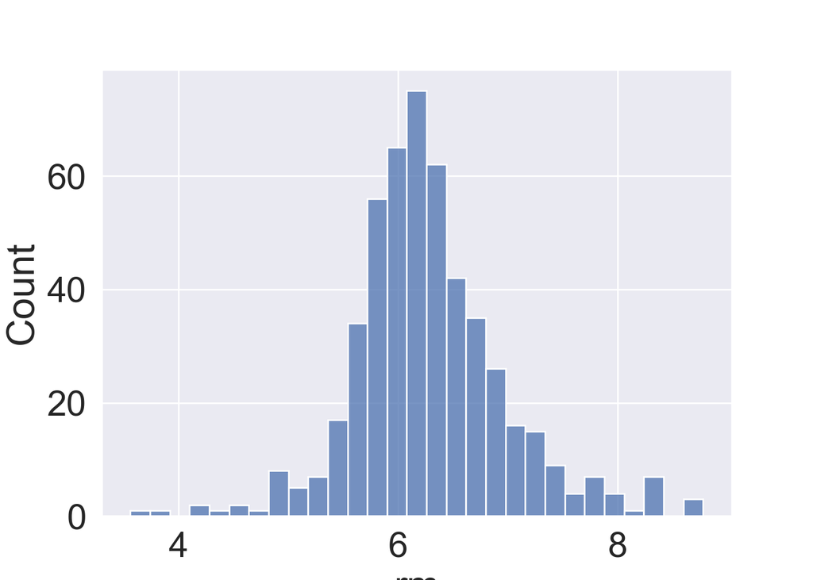

```python
plt.clf()
sns.histplot(data = Boston, x = 'rm')
plt.show()
```

```python
Boston[Boston['rm'] > 8]
```

```
        crim    zn  indus  chas     nox     rm   age     dis  rad  tax  \
98   0.12083   0.0   2.89     0  0.4450  8.069  76.0  3.4952    2  276
164  1.51902   0.0  19.58     1  0.6050  8.375  93.9  2.1620    5  403
205  0.02009  95.0   2.68     0  0.4161  8.034  31.9  5.1180    4  224
225  0.31533   0.0   6.20     0  0.5040  8.266  78.3  2.8944    8  307
226  0.52693   0.0   6.20     0  0.5040  8.725  83.0  2.8944    8  307
227  0.38214   0.0   6.20     0  0.5040  8.040  86.5  3.2157    8  307
233  0.57529   0.0   6.20     0  0.5070  8.337  73.3  3.8384    8  307
234  0.33147   0.0   6.20     0  0.5070  8.247  70.4  3.6519    8  307
254  0.36894  22.0   5.86     0  0.4310  8.259   8.4  8.9067    7  330
258  0.61154  20.0   3.97     0  0.6470  8.704  86.9  1.8010    5  264
263  0.52014  20.0   3.97     0  0.6470  8.398  91.5  2.2885    5  264
268  0.57834  20.0   3.97     0  0.5750  8.297  67.0  2.4216    5  264
365  3.47428   0.0  18.10     1  0.7180  8.780  82.9  1.9047   24  666

     ptratio  lstat  medv
98      18.0   4.21  38.7
164     14.7   3.32  50.0
205     14.7   2.88  50.0
225     17.4   4.14  44.8
226     17.4   4.63  50.0
227     17.4   3.13  37.6
233     17.4   2.47  41.7
234     17.4   3.95  48.3
254     19.1   3.54  42.8
258     13.0   5.12  50.0
263     13.0   5.91  48.8
268     13.0   7.44  50.0
365     20.2   5.29  21.9
```

## 5 ISL Exercise 3.7.3 (12pts)

Suppose we have a data set with five predictors, $X_1 = \text{GPA}$, $X_2 = \text{IQ}$, $X_3 = \text{Level (1 for College and 0 for High School)}$, $X_4 = \text{Interaction between GPA and IQ}$, and $X_5 = \text{Interaction between GPA and Level}$. The response is starting salary after graduation (in thousands of dollars). Suppose we use least squares to fit the model, and get $\hat\beta_0 = 50$, $\hat\beta_1 = 20$, $\hat\beta_2 = 0.07$, $\hat\beta_3 = 35$, $\hat\beta_4 = 0.01$, $\hat\beta_5 = −10$.

The model is
$$\text{salary} \approx \beta_0 + \beta_1 \times \text{GPA} + \beta_2 \times \text{IQ} + \beta_3 \times \text{Level} + \beta_4 \times (\text{GPA} \times \text{IQ}) + \beta_5 \times (\text{GPA} \times \text{Level})$$

### 5.1 (a)

Which answer is correct, and why?

- For a fixed value of IQ and GPA, high school graduates earn more, on average, than college graduates.
- For a fixed value of IQ and GPA, college graduates earn more, on average, than high school graduates.
- For a fixed value of IQ and GPA, high school graduates earn more, on average, than college graduates provided that the GPA is high enough.
- For a fixed value of IQ and GPA, college graduates earn more, on average, than high school graduates provided that the GPA is high enough.

### 5.2 (b)

Predict the salary of a college graduate with IQ of 110 and a GPA of 4.0.

### 5.3 (c)

True or false: Since the coeﬀicient for the GPA/IQ interaction term is very small, there is very little evidence of an interaction effect. Justify your answer.

**Solution**

Depending on the standard error, the p-value of interaction term can be very small thus significant.

## 6 ISL Exercise 3.7.15 (20pts)

This problem involves the `Boston` data set, which we saw in the lab for this chapter. We will now try to predict per capita crime rate using the other variables in this data set. In other words, per capita crime rate is the response, and the other variables are the predictors.

### 6.1 (a)

For each predictor, fit a simple linear regression model to predict the response. Describe your results. In which of the models is there a statistically significant association between the predictor and the response? Create some plots to back up your assertions.

**Solution**

- Retrieve simple linear regression (SLR) coefficients by loop

**R**

```r
library(gtsummary)
crim.fit <- lm(crim ~ . , data = Boston)
summary(crim.fit)
```

```
Call:
lm(formula = crim ~ ., data = Boston)

Residuals:
   Min     1Q Median     3Q    Max
-8.534 -2.248 -0.348  1.087 73.923

Coefficients:
              Estimate Std. Error t value Pr(>|t|)
(Intercept) 13.7783938  7.0818258   1.946 0.052271 .
zn           0.0457100  0.0187903   2.433 0.015344 *
indus       -0.0583501  0.0836351  -0.698 0.485709
chas        -0.8253776  1.1833963  -0.697 0.485841
nox         -9.9575865  5.2898242  -1.882 0.060370 .
rm           0.6289107  0.6070924   1.036 0.300738
age         -0.0008483  0.0179482  -0.047 0.962323
dis         -1.0122467  0.2824676  -3.584 0.000373 ***
rad          0.6124653  0.0875358   6.997 8.59e-12 ***
tax         -0.0037756  0.0051723  -0.730 0.465757
ptratio     -0.3040728  0.1863598  -1.632 0.103393
lstat        0.1388006  0.0757213   1.833 0.067398 .
medv        -0.2200564  0.0598240  -3.678 0.000261 ***
---
Signif. codes:  0 '***' 0.001 '**' 0.01 '*' 0.05 '.' 0.1 ' ' 1

Residual standard error: 6.46 on 493 degrees of freedom
Multiple R-squared:  0.4493,    Adjusted R-squared:  0.4359
F-statistic: 33.52 on 12 and 493 DF,  p-value: < 2.2e-16
```

**Python**

```python
import statsmodels.api as sm
import statsmodels.formula.api as smf

# Fit separate simple linear regressions
cols = Boston.columns.difference(['crim']) # all cols except crim
cols
```

```
Index(['age', 'chas', 'dis', 'indus', 'lstat', 'medv', 'nox', 'ptratio', 'rad',
       'rm', 'tax', 'zn'],
      dtype='object')
```

```python
slr_coefs = [
  smf.ols(formula = 'crim ~ ' + col, data = Boston).fit().params[1]
  for col in cols
  ]
slr_coefs
```

[output not shown]

```python
res_df = pd.DataFrame({'slr_betahat': slr_coefs}, index = cols)
res_df
```

```
         slr_betahat
age         0.107786
chas       -1.892777
dis        -1.550902
indus       0.509776
lstat       0.548805
medv       -0.363160
nox        31.248531
ptratio     1.151983
rad         0.617911
rm         -2.684051
tax         0.029742
zn         -0.073935
```

### 6.2 (b)

Fit a multiple regression model to predict the response using all of the predictors. Describe your results. For which predictors can we reject the null hypothesis $\text{H}_0: \beta_j = 0$?

**Solution**

Retrieve multiple linear regression (MLR) coefficients and contrast to SLR coefficients.

**R**

```r
lm(crim ~ ., data = Boston) %>%
  tbl_regression() %>%
  bold_labels() %>%
  bold_p(t = 0.05)
```

| **Characteristic** | **Beta** | **95% CI** <sup>1</sup> | **p-value** |
| --- | --- | --- | --- |
| zn | 0.05 | 0.01, 0.08 | 0.015 |
| indus | -0.06 | -0.22, 0.11 | 0.5 |
| chas | -0.83 | -3.2, 1.5 | 0.5 |
| nox | -10 | -20, 0.44 | 0.060 |
| rm | 0.63 | -0.56, 1.8 | 0.3 |
| age | 0.00 | -0.04, 0.03 | >0.9 |
| dis | -1.0 | -1.6, -0.46 | <0.001 |
| rad | 0.61 | 0.44, 0.78 | <0.001 |
| tax | 0.00 | -0.01, 0.01 | 0.5 |
| ptratio | -0.30 | -0.67, 0.06 | 0.10 |
| lstat | 0.14 | -0.01, 0.29 | 0.067 |
| medv | -0.22 | -0.34, -0.10 | <0.001 |

<sup>1</sup> CI = Confidence Interval

**Python**

```python
mlr_coefs = smf.ols(formula = 'crim ~ ' + "+".join(cols), data = Boston).fit().params.to_frame(name = 'mlr_betahat')
res_df = res_df.join(mlr_coefs) # left-join by default
res_df
```

```
         slr_betahat  mlr_betahat
age         0.107786    -0.000848
chas       -1.892777    -0.825378
dis        -1.550902    -1.012247
indus       0.509776    -0.058350
lstat       0.548805     0.138801
medv       -0.363160    -0.220056
nox        31.248531    -9.957587
ptratio     1.151983    -0.304073
rad         0.617911     0.612465
rm         -2.684051     0.628911
tax         0.029742    -0.003776
zn         -0.073935     0.045710
```

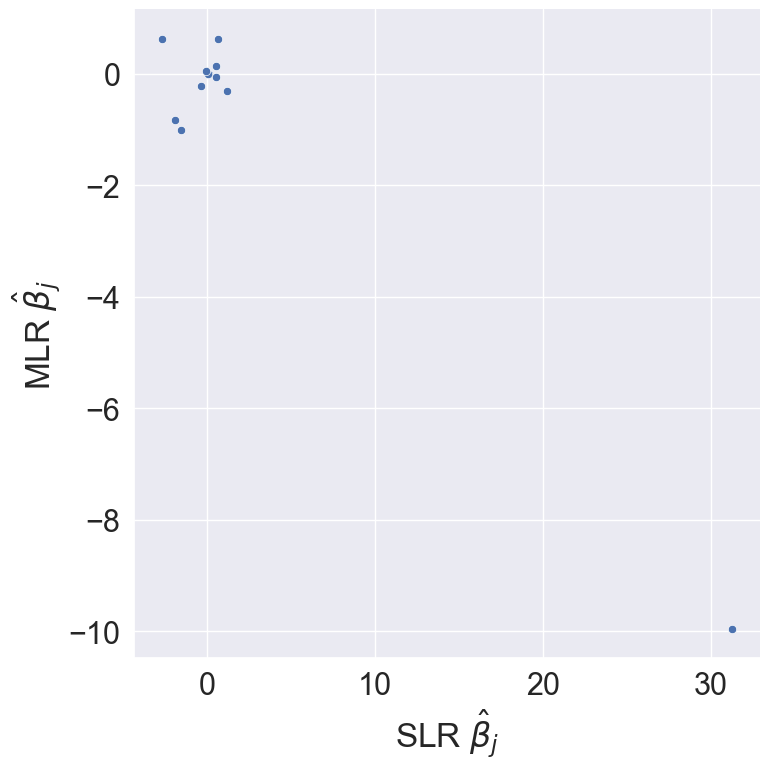

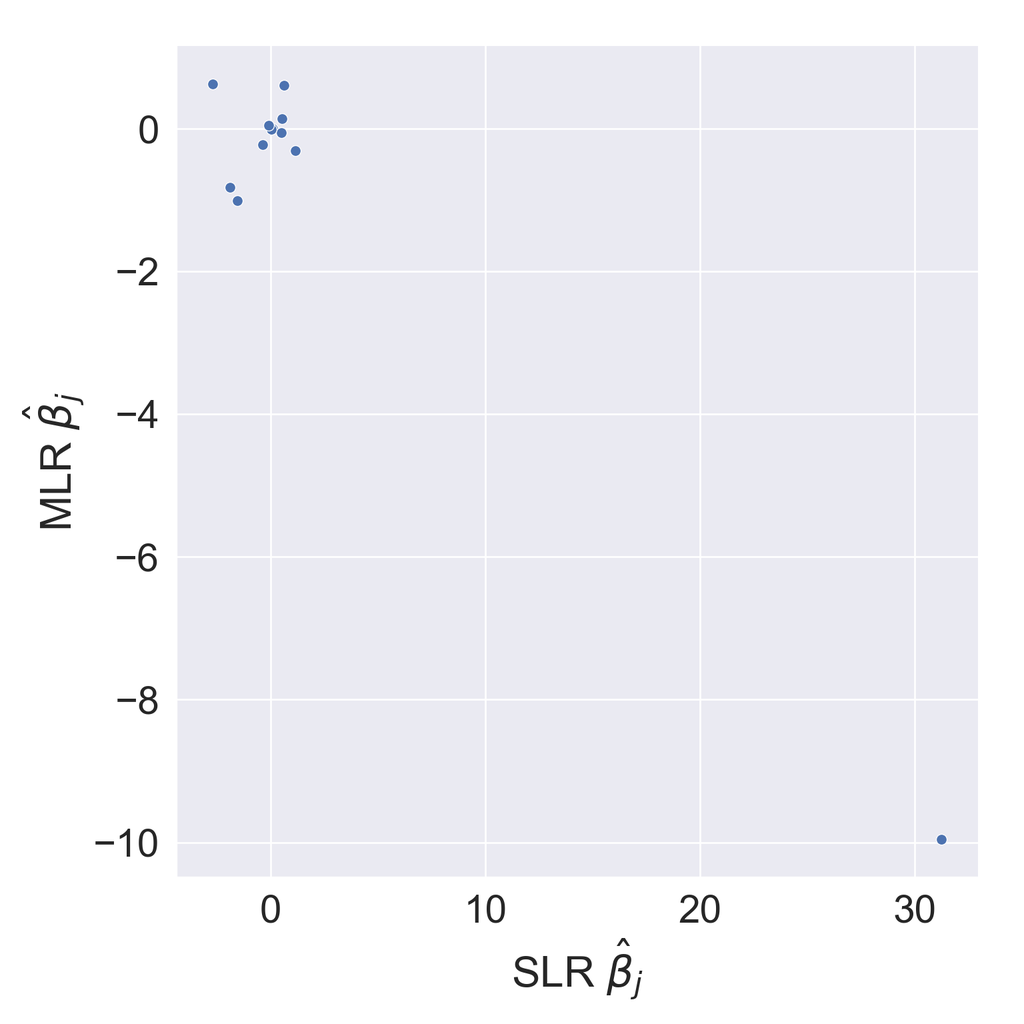

```python
sns.relplot(
  data = res_df,
  x = 'slr_betahat',
  y = 'mlr_betahat',
  height = 8).set(
  xlabel = r'SLR $\hat{\beta}_j$',
  ylabel = r'MLR $\hat{\beta}_j$',
)
```

### 6.3 (c)

How do your results from (a) compare to your results from (b)? Create a plot displaying the univariate regression coeﬀicients from (a) on the x-axis, and the multiple regression coeﬀicients from (b) on the y-axis. That is, each predictor is displayed as a single point in the plot. Its coeﬀicient in a simple linear regression model is shown on the x-axis, and its coeﬀicient estimate in the multiple linear regression model is shown on the y-axis.

### 6.4 (d)

Is there evidence of non-linear association between any of the predictors and the response? To answer this question, for each predictor X, fit a model of the form

$$Y= \beta_0 + \beta_1X_1 + \beta_2X_2 + \beta_3X_3 + \epsilon.$$

## 7 Bonus question (20pts)

For multiple linear regression, show that $R^2$ is equal to the correlation between the response vector $\mathbf{y} = (y_1, \ldots, y_n)^T$ and the fitted values $\hat{\mathbf{y}} = (\hat y_1, \ldots, \hat y_n)^T$. That is
$$R^2 = 1 - \frac{\text{RSS}}{\text{TSS}} = [\operatorname{Cor}(\mathbf{y}, \hat{\mathbf{y}})]^2.$$

### 7.1 Solution

- Recall that
  $$\begin{eqnarray*}
  \operatorname{Cor} (\mathbf{x}, \mathbf{y}) & = & \frac{\sum_i (x_i - \bar{x}) (y_i - \bar{y})} {\sqrt{\sum_i(x_i - \bar{x})^2 \sum_i(y_i - \bar{y})^2}}\\
  & = & \frac{( \mathbf{x} - \frac{\mathbf{J}}{n}\mathbf{x} )^T (\mathbf{y} - \frac{\mathbf{J}}{n}\mathbf{y})}{\sqrt{(\mathbf{x} - \frac{\mathbf{J}}{n}\mathbf{x})^T (\mathbf{x} - \frac{\mathbf{J}}{n}\mathbf{x}) (\mathbf{y} - \frac{\mathbf{J}}{n}\mathbf{y})^T(\mathbf{y} - \frac{\mathbf{J}}{n}\mathbf{y})}}\\
  \end{eqnarray*}$$
  where
  $$\mathbf{J} = \mathbf{1}\mathbf{1}^T = \begin{pmatrix} 1 & 1 & \cdots & 1 \\ 1 & 1 & \cdots & 1 \\ \vdots & \vdots & \ddots & \vdots \\ 1 & 1 & \cdots & 1 \end{pmatrix}_{n \times n}.$$
- And for $\operatorname{R}^2$
  $$\operatorname{R}^2 = 1-\frac{\text{RSS}} {\text{TSS}} = 1 - \frac{\sum_i (y_i- \hat{y}_i)^2}{\sum_i (y_i- \bar{y}_i)^2}$$
  and
  $$\operatorname{R}^2 = 1 - \frac{\sum_i (y_i- \hat{y}_i)^2}{\sum_i (y_i- \bar{y}_i)^2} = 1 - \frac{(\mathbf{Y}-\mathbf{H}\mathbf{Y})^T(\mathbf{Y}-\mathbf{H}\mathbf{Y})}{(\mathbf{Y}-\frac{\mathbf{J}}{n}\mathbf{Y})^T(\mathbf{Y}-\frac{\mathbf{J}}{n}\mathbf{Y})} = 1 - \frac{\mathbf{Y}^T(\mathbf{I}-\mathbf{H})^T(\mathbf{I}-\mathbf{H})\mathbf{Y}}{\mathbf{Y}^T(\mathbf{I}-\frac{\mathbf{J}}{n})^T(\mathbf{I}-\frac{\mathbf{J}}{n})\mathbf{Y}}$$
  Therefore,
  $$\operatorname{R}^2 = 1 - \frac{\mathbf{Y}^T(\mathbf{I}-\mathbf{H})\mathbf{Y}}{\mathbf{Y}^T(\mathbf{I}-\frac{\mathbf{J}}{n})\mathbf{Y}}$$
  where $\mathbf{H} = \mathbf{X}(\mathbf{X}^T\mathbf{X})^{-1}\mathbf{X}^T$ is a projection matrix and so as $\mathbf{I}-\mathbf{H}$.

Now, I will use $H_{\mathbf{1}_n}$ to be $\frac{\mathbf{J}}{n}$.

$$\begin{eqnarray*}
[\operatorname{Cor}(\mathbf{y}, \hat{\mathbf{y}})]^2 &=& \frac{[\langle (I - H_{\mathbf{1}_n}) H_{\mathbf{X}} \mathbf{y}, (I - H_{\mathbf{1}_n}) \mathbf{y} \rangle]^2}{\|(I - H_{\mathbf{1}_n}) H_{\mathbf{X}} \mathbf{y}\|^2 \|(I - H_{\mathbf{1}_n}) \mathbf{y}\|^2} \\
&=& \frac{[\mathbf{y}^T H_{\mathbf{X}} (I - H_{\mathbf{1}_n}) \mathbf{y}]^2}{[\mathbf{y}^T H_{\mathbf{X}} (I - H_{\mathbf{1}_n}) H_{\mathbf{X}} \mathbf{y}][\mathbf{y}^T (I - H_{\mathbf{1}_n}) \mathbf{y}]} \\
& & (\text{now } \mathbf{y}^T H_{\mathbf{X}} (I - H_{\mathbf{1}_n}) H_{\mathbf{X}} \mathbf{y} = \mathbf{y}^T H_{\mathbf{X}} \mathbf{y} - \mathbf{y}^T H_{\mathbf{1}_n} H_{\mathbf{X}} \mathbf{y} = \mathbf{y}^T H_{\mathbf{X}} (I - H_{\mathbf{1}_n}) \mathbf{y}) \\
&=& \frac{|\mathbf{y}^T H_{\mathbf{X}} (I - H_{\mathbf{1}_n}) \mathbf{y}|}{\mathbf{y}^T (I - H_{\mathbf{1}_n}) \mathbf{y}} \\
&=& \frac{|\mathbf{y}^T H_{\mathbf{X}} \mathbf{y} - \mathbf{y}^T H_{\mathbf{1}_n} \mathbf{y}|}{\mathbf{y}^T (I - H_{\mathbf{1}_n}) \mathbf{y}} \\
&=& \frac{\mathbf{y}^T (\mathbf{I} - H_{\mathbf{1}_n}) \mathbf{y} - \mathbf{y}^T (\mathbf{I} - H_{\mathbf{X}}) \mathbf{y}}{\mathbf{y}^T (I - H_{\mathbf{1}_n}) \mathbf{y}} \\
&=& 1 - \frac{\text{RSS}}{\text{TSS}}.
\end{eqnarray*}$$

## 8 TA Reports

### 8.1 James

- Q1) Many students had a correct solution, a few assumed the defined optimal solution was optimal and used that to prove that it was optimal which is circular.
- Q2) Students did generally well here. A few did not have their graph display, one had test and train error inverted.
- Q3) Almost all students got this entirely correct a few did not answer it in full.
- Q4) 4d) was the major issue with many not identifying or justifying “exceptional values.” In 4g several only identified a single minimum when two tracts were tied.
- Q5) The wording tripped up some as they selected IV instead of III). One student got the calculation wrong for 5.2. Several got 5.3 wrong as they thought a small coefficient was insignificant.
- Q6) In part c) many students provided a graph without explanation of how the coefficients compared.
- Bonus) Many students asserted that $\text{cov}(y, \hat y) = \text{var}(\hat y)$ without justification. For a question of this type I figured they needed to actually prove this under the assumptions of multiple linear regression. Only two students gave a proof I accepted as sufficiently complete.

### 8.2 Yingxin

- Q1: For Q1.1, some students were unclear on how to begin their proof. Additionally, a few students were unable to complete the proof for Q1.2.
- Q2: Most students were able to create the sketch using either R or handwriting, but some encountered issues displaying their plots in the HTML file due to incorrect settings.
- Q3: All students provided some applications.
- Q4: Most students completed this question well. However, many were unfamiliar with the concept of “outliers” in Q4.4, and some only identified one of the two lowest medv tracts in Q4.7.
- Q5: While most students performed well, some selected extra choices instead of the correct option (iii) in Q5.1, and two students miscalculated their results for Q5.2.
- Q6: All students completed this question correctly.
- Bonus: All students who attempted the bonus missed the proof of $\sum {(y_i - \hat y_i)(\hat y_i - \bar y)} = 0$ or a similar key step.